# Analyzing Medical Insurance Costs with Cross-Validation

## Baseline model

Our model is a Multiple Linear Regression model of individual medical charges on age, sex, BMI, number of children, smoker status, and region. I chose this model because it aligns perfectly with the research question mentioned above, while being easily interpretable: each prediction coefficient gives the average change in charges, associated with a one-unit change in that predictor while holding the others constant. This results in the final model being:

```r
library(tidyverse)

insurance_data <- read.csv("insurance.csv", stringsAsFactors = TRUE)
summary(insurance_data)
```

```
      age            sex           bmi           children     smoker
 Min.   :18.00   female:662   Min.   :15.96   Min.   :0.000   no :1064
 1st Qu.:27.00   male  :676   1st Qu.:26.30   1st Qu.:0.000   yes: 274
 Median :39.00                Median :30.40   Median :1.000
 Mean   :39.21                Mean   :30.66   Mean   :1.095
 3rd Qu.:51.00                3rd Qu.:34.69   3rd Qu.:2.000
 Max.   :64.00                Max.   :53.13   Max.   :5.000
       region       charges
 northeast:324   Min.   : 1122
 northwest:325   1st Qu.: 4740
 southeast:364   Median : 9382
 southwest:325   Mean   :13270
                 3rd Qu.:16640
                 Max.   :63770
```

```r
baseline_insurance_model <- lm(charges ~ age + sex + bmi + children + smoker + region, data = insurance_data)
summary(baseline_insurance_model)
```

```
Call:
lm(formula = charges ~ age + sex + bmi + children + smoker +
    region, data = insurance_data)

Residuals:
     Min       1Q   Median       3Q      Max
-11304.9  -2848.1   -982.1   1393.9  29992.8

Coefficients:
                Estimate Std. Error t value Pr(>|t|)
(Intercept)     -11938.5      987.8 -12.086  < 2e-16 ***
age                256.9       11.9  21.587  < 2e-16 ***
sexmale           -131.3      332.9  -0.394 0.693348
bmi                339.2       28.6  11.860  < 2e-16 ***
children           475.5      137.8   3.451 0.000577 ***
smokeryes        23848.5      413.1  57.723  < 2e-16 ***
regionnorthwest   -353.0      476.3  -0.741 0.458769
regionsoutheast  -1035.0      478.7  -2.162 0.030782 *
regionsouthwest   -960.0      477.9  -2.009 0.044765 *
---
Signif. codes:  0 '***' 0.001 '**' 0.01 '*' 0.05 '.' 0.1 ' ' 1

Residual standard error: 6062 on 1329 degrees of freedom
Multiple R-squared:  0.7509,    Adjusted R-squared:  0.7494
F-statistic: 500.8 on 8 and 1329 DF,  p-value: < 2.2e-16
```

```r
confint(baseline_insurance_model)
```

```
                      2.5 %       97.5 %
(Intercept)     -13876.3934 -10000.68373
age                233.5138    280.19893
sexmale           -784.4703    521.84155
bmi                283.0884    395.29848
children           205.1633    745.83780
smokeryes        23038.0307  24659.03838
regionnorthwest  -1287.2982    581.37040
regionsoutheast  -1974.0968    -95.94733
regionsouthwest  -1897.6364    -22.46560
```

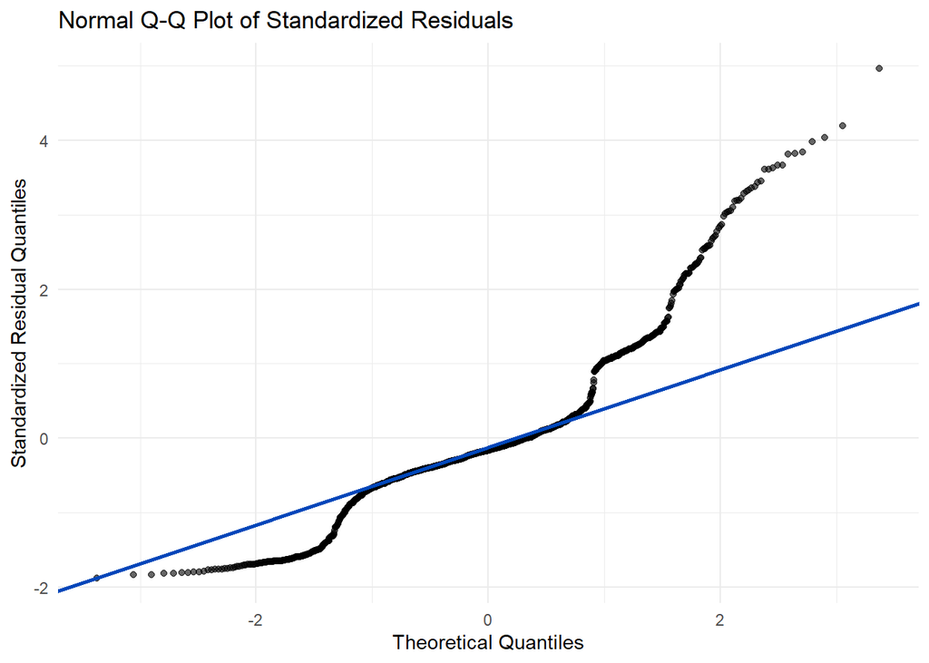

```r
# Diagnostics (I don't know if we need this or not, so I'll use one model from each test to test for each individual diagnostic)
insurance_aug <- insurance_data |> mutate(std_residual = rstandard(baseline_insurance_model))

ggplot(insurance_aug, aes(sample = std_residual)) +
  stat_qq(alpha = 0.6) +
  stat_qq_line(color = "#0047BA", linewidth = 1) +
  labs(x = "Theoretical Quantiles",
       y = "Standardized Residual Quantiles",
       title = "Normal Q-Q Plot of Standardized Residuals") +
  theme_minimal()
```

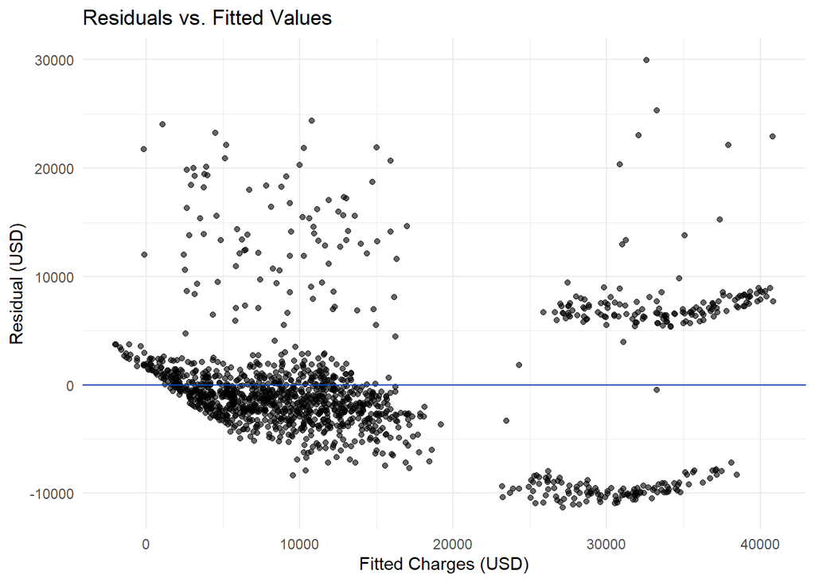

```r
insurance_aug2 <- insurance_data |>
  mutate(fitted   = fitted(baseline_insurance_model),
         residual = resid(baseline_insurance_model))

insurance_aug2 |>
  ggplot(aes(x = fitted, y = residual)) +
  geom_point(alpha = 0.6) +
  geom_hline(yintercept = 0, color = "#0047BA") +
  labs(x = "Fitted Charges (USD)",
       y = "Residual (USD)",
       title = "Residuals vs. Fitted Values") +
  theme_minimal()
```

The above analysis shows our baseline model to be:

$$\widehat{\text{charges}} = -11938.5 + 256.9(\text{age}) - 131.3(\text{male}) + 339.2(\text{bmi}) + 475.5(\text{children}) + 23848.5(\text{smoker}) - 353.0(\text{NW}) - 1035.0(\text{SE}) - 960.0(\text{SW})$$

Holding age, sex, BMI, children and region constant, smokers are predicted to be billed $23,850 more on average than non-smokers (95% CI: ~$23,040 to ~$24,660 . Smoking status is by far the strongest predictor in the model. One specific limitation of this model can be seen while looking at the Q-Q plot. The data is obviously not normal, and seems pretty scary. We will test out every transformation to see which model would result in the best fit. Following that, we will use a series of tests to determine which algorithm we should use to finalize our model under a certain metric. This is just the beginning, but we will ensure that our finalized model will have much prettier diagnostics than the baseline model we have.

## Where the analysis could go

**Choose two different course-method families from the project instructions. For each, state what you might do and how it could help answer the question. These methods will form the core of the project and may change after feedback.**

1. **Possible direction:** Use cross-validation and a training/test split to evaluate how accurately the model predicts medical insurance costs for individuals not used to fit the model. This could help determine whether the model produces reliable cost estimates for new policyholders and whether its predictions could be useful when developing insurance premiums.(A more Actuarial specific approach)
2. **Possible direction:** Use multiple linear regression to model medical insurance charges based on available predictors such as age, BMI, smoking status, sex, and number of children. From an actuarial perspective, this could help an insurer estimate an individual’s expected medical costs and understand which characteristics are most useful for predicting those costs.

## AI disclosure and sources

**Question and Audience** - No AI

**Data** - No AI

**Baseline Model** - AI was used to make the baseline model look beautifully embedded into the qmd file, as well as fixing the code to augment the data which allowed it to run both the Q-Q plot and Residuals vs Fitted Value plot.

**Where the analysis could go** - Used AI to come up with a second direction we could possibly take the project as a backup.